# Introduction to Bayesian Inference

Evan Carey, created for BH Analytics

# Bayes Theorem versus Bayesian Inference

- Bayesian inference comes from a probability theorem called ‘Bayes Theorem’
- This is related but different from performing Bayesian inference!
- The focus of this material will be Bayesian inference, but we will briefly discuss Bayes Theorem for context.
- We first need to think about probability statements. Imagine there is a medical screening test that is highly accurate, so that 99% of people with the disease would screen positive. We can express this like so:

$$P(\text{positive test}\mid \text{having disease}) = 0.99$$

> Question: If someone has a positive screening test, what is the probability they have the disease? Should they be worried?

# Bayes Theorem

- We actually need more information to answer this! We cannot simply invert the conditional parts, in other words:

$$P(\text{positive test}\mid \text{having disease}) \neq P( \text{having disease}\mid\text{positive test})$$

- This is sometimes called the [prosecutors fallacy](https://en.wikipedia.org/wiki/Prosecutor%27s_fallacy).
- In order to relate these two probabilities, we can invoke Bayes theorem!

$$P(A\mid B) = \frac{P(B\mid A) * P(A)}{P(B)}$$

- So what if I gave you the following information, can you answer the question?

> Question: If someone has a positive screening test, what is the probability they have the disease?

> The overall disease rate in the population is 0.1%, the probability of a positive test in those with the disease is 99% (sensitive), and the probability of a negative test in those without the disease is 99% (specific).
- Here is another probability hint to solve the denominator:

$$P(B) = P(B|A)*P(A) + P(B|\text{Not }A)*P(\text{Not }A)$$
Take a moment and try to solve this problem!

# Answer to Problem

$$P(\text{having disease} \mid \text{positive test}) = \frac{P(\text{positive test}\mid \text{having disease}) * \text{having disease}}{P(\text{positive test)}}$$

$$P(\text{having disease} \mid \text{positive test}) = \frac{P(\text{positive test}\mid \text{having disease}) * \text{having disease}}{P(\text{positive test}\mid\text{having disease})*P(\text{having disease}) + P(\text{positive test}\mid\text{no disease})*P(\text{no disease})}$$

$$P(\text{having disease} \mid \text{positive test}) = \frac{(0.99) * (.001)}{(0.99*.001) + (0.01*0.999))}$$

$$P(\text{having disease} \mid \text{positive test}) = 0.09$$

# What about Bayesian Inference?

So what does that have to do with Bayesian inference?!? Truly, they are related but different things. We adopt the same sort of Bayes theorem equation, but apply it to making inference unknown parameters, given we have observed data.

- We are usually interested in answering the question: what do we think reasonable values of our parameters, given the data we just observed? A parameter might be ‘The difference in average weight loss between drug A and drug B’, or others…Recall Bayes Theorem:

$$P(A\mid B) = \frac{P(B\mid A) * P(A)}{P(B)}$$

- We can link the Bayesian approach like this:

$$P(\text{parameters} \mid \text{data}) = \frac{P(\text{data}\mid \text{parameters}) * P(\text{parameters})}{P(\text{average likelihood of data})}$$

- But functionally you might just think of this:

$$\text{posterior} = \text{likelihood of data} * \text{prior}$$

- Or equivalently this:

$$\text{updated information} = \text{data from experiment} * \text{prior information}$$

- Let’s think about how we define this in the context of a simple example.

# Example Inference - Normal Distribution

- Say we have measured several weights of humans in an experiment like this:

```r
# simple data summary
weights <- c(180, 210, 155, 165, 145)
```

- For now we will keep it simple, there are no other variables. Where did this data come from? How can we describe the data generating process (or make **inference** on it) using this data? We first need to decide on a general model of where the data came from. Let’s say we assume the data came from a normal distribution (bell shaped curve). We can describe this like so:

$$\text{Weight}_i \sim \text{Normal}(\mu, \sigma)$$

And the normal distribution is given by the probability density:

$$f(x \mid \mu, \sigma^2) = \frac{1}{\sqrt{2\pi\sigma^2}}e^{-\frac{(x-\mu)^2}{2\sigma^2}}$$

Here is the ‘shape’ of the standard normal distribution with $\mu=0$ and $\sigma=1$ :

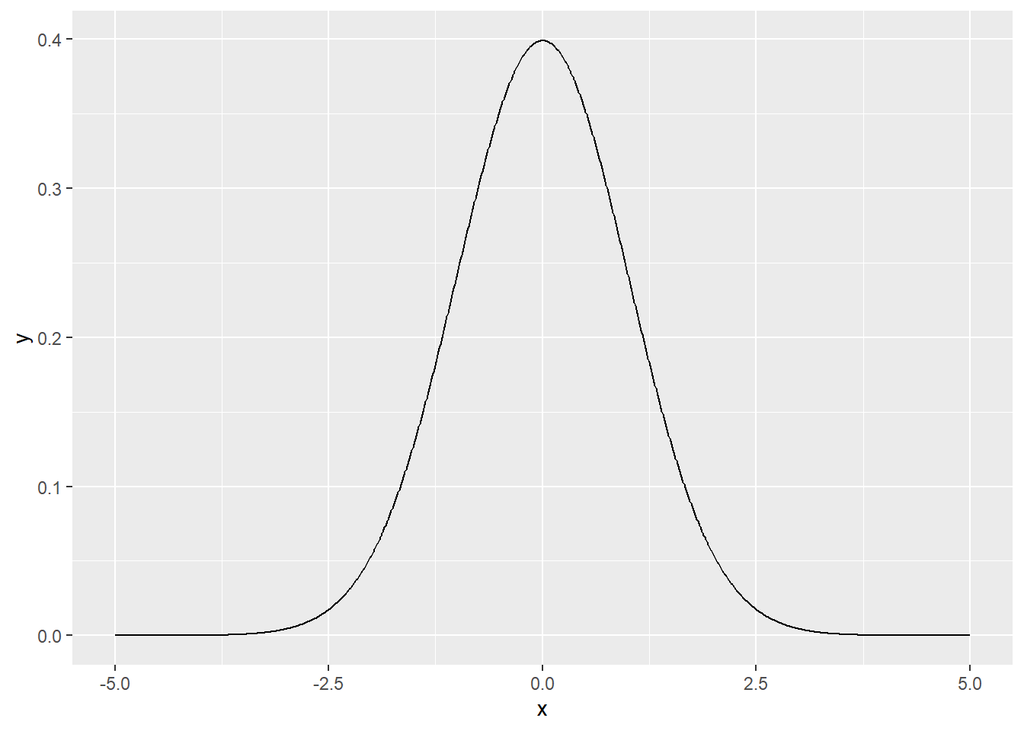

```r
x=seq(-5,5,length.out = 1000)
y=dnorm(x,mean = 0,sd = 1)
library(ggplot2)
qplot(x,y,geom = 'line')
```

- Now that we have defined the model, we need to estimate reasonable values for $\sigma$ and $\mu$. We can do this with a linear regression with only an intercept.

# Estimation - REML versus MCMC

- In the traditional frequentist framework, we would use something called restricted maximum likelihood to find solve for $\sigma$ and $\mu$.

```r
# Frequentist REML approach
df1 <- data.frame(weights)
summary(glm(weights~1, data=df1))
```

```
##
## Call:
## glm(formula = weights ~ 1, data = df1)
##
## Deviance Residuals:
##   1    2    3    4    5
##   9   39  -16   -6  -26
##
## Coefficients:
##             Estimate Std. Error t value Pr(>|t|)
## (Intercept)   171.00      11.34   15.09 0.000113 ***
## ---
## Signif. codes:  0 '***' 0.001 '**' 0.01 '*' 0.05 '.' 0.1 ' ' 1
##
## (Dispersion parameter for gaussian family taken to be 642.5)
##
##     Null deviance: 2570  on 4  degrees of freedom
## Residual deviance: 2570  on 4  degrees of freedom
## AIC: 49.401
##
## Number of Fisher Scoring iterations: 2
```

- However, we will focus on Bayesian inference, using Markov Chain Monte Carlo (MCMC) to identify the posterior.
- Here is some basic code for fitting this model (more on the details in a moment)

```r
library(rstanarm)
# Fit Bayesian model
fit1 <- stan_glm(weights~1, data=df1)
# Explore Results
fit1
```

```
## stan_glm
##  family:       gaussian [identity]
##  formula:      weights ~ 1
##  observations: 5
##  predictors:   1
## ------
##             Median MAD_SD
## (Intercept) 170.6   11.9
##
## Auxiliary parameter(s):
##       Median MAD_SD
## sigma 26.9    8.7
##
## ------
## * For help interpreting the printed output see ?print.stanreg
## * For info on the priors used see ?prior_summary.stanreg
```

```r
summary(fit1)
```

```
##
## Model Info:
##  function:     stan_glm
##  family:       gaussian [identity]
##  formula:      weights ~ 1
##  algorithm:    sampling
##  sample:       4000 (posterior sample size)
##  priors:       see help('prior_summary')
##  observations: 5
##  predictors:   1
##
## Estimates:
##               mean   sd    10%   50%   90%
## (Intercept) 170.5   13.4 154.1 170.6 186.5
## sigma        29.3   11.0  18.2  26.9  43.4
##
## Fit Diagnostics:
##            mean   sd    10%   50%   90%
## mean_PPD 170.4   19.3 147.3 170.5 194.0
##
## The mean_ppd is the sample average posterior predictive distribution of the outcome variable (for details see help('summary.stanreg')).
##
## MCMC diagnostics
##               mcse Rhat n_eff
## (Intercept)   0.3  1.0  1491
## sigma         0.3  1.0  1458
## mean_PPD      0.4  1.0  2166
## log-posterior 0.0  1.0  1271
##
## For each parameter, mcse is Monte Carlo standard error, n_eff is a crude measure of effective sample size, and Rhat is the potential scale reduction factor on split chains (at convergence Rhat=1).
```

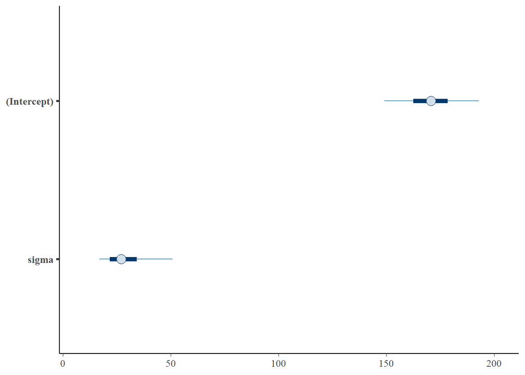

```r
plot(fit1)
```

- What does all this output mean? More on this later - we will talk through it.

# Priors

- Recall the full Bayesian framework:

$$\text{updated information} = \text{data from experiment} * \text{prior information}$$

- We haven’t really mentioned the priors yet. It turns out the `rstanarm` package will give sensible priors by default, which are designed to be ‘weakly informative’. The results should be primarily driven by the data (not the priors), but the priors will be stabilizing. We can explore these default priors like so:

```r
# What about the priors?
prior_summary(fit1)
```

```
## Priors for model 'fit1'
## ------
## Intercept (after predictors centered)
##   Specified prior:
##     ~ normal(location = 171, scale = 2.5)
##   Adjusted prior:
##     ~ normal(location = 171, scale = 63)
##
## Auxiliary (sigma)
##   Specified prior:
##     ~ exponential(rate = 1)
##   Adjusted prior:
##     ~ exponential(rate = 0.039)
## ------
## See help('prior_summary.stanreg') for more details
```

```r
# Check the standard deviation
sd(weights)
```

```
## [1] 25.34758
```

- The priors are listed for each parameter. The adjusted prior is the distribution adjusted based on the scale of the predictors. Since the standard deviation of the weights vector is ~25, 2.5 standard deviations is ~ 63 (the adjusted prior). RSTANARM also automatically picks the mean as the center of the prior distribution (location = 171) for the intercept.
- So what does this mean? In the Bayesian framework, we are taking the observed data, combining it with the prior distributions (for each unknown parameter), then generating a posterior by combining those two things together. We can easily visualize the prior distributions versus the posterior for each parameter in the model:

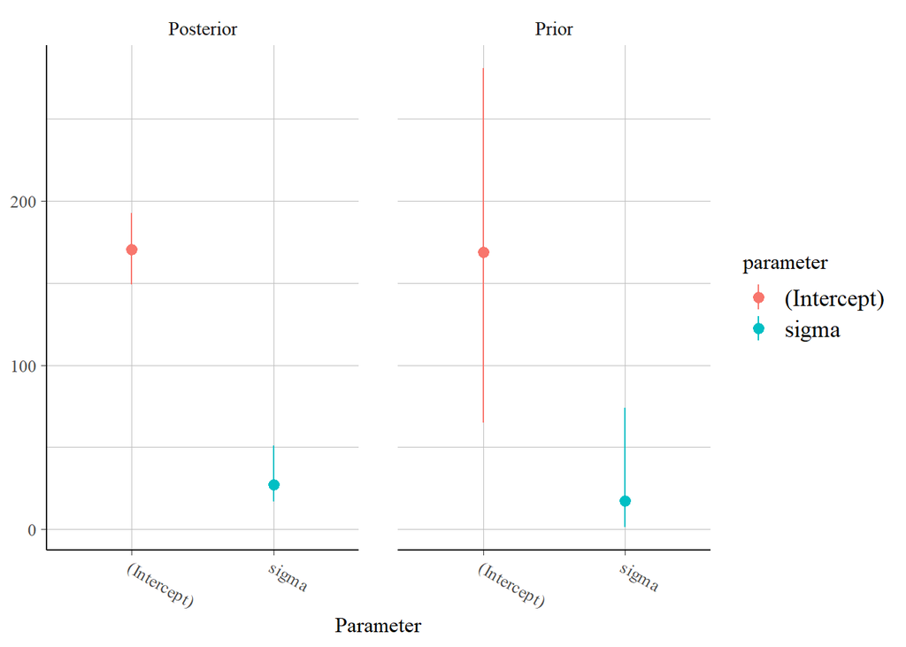

```r
# visualize the priors versus the posterior distribution
posterior_vs_prior(fit1)
```

```r
# help("priors", package = "rstanarm")
```

- We are saying the following: prior to fitting the model, we believe the average weight is most likely 171, but the probability of the mean weight can be summarized with a normal distribution with location = 171 and sd = 63. This graph summarizes those probabilities:

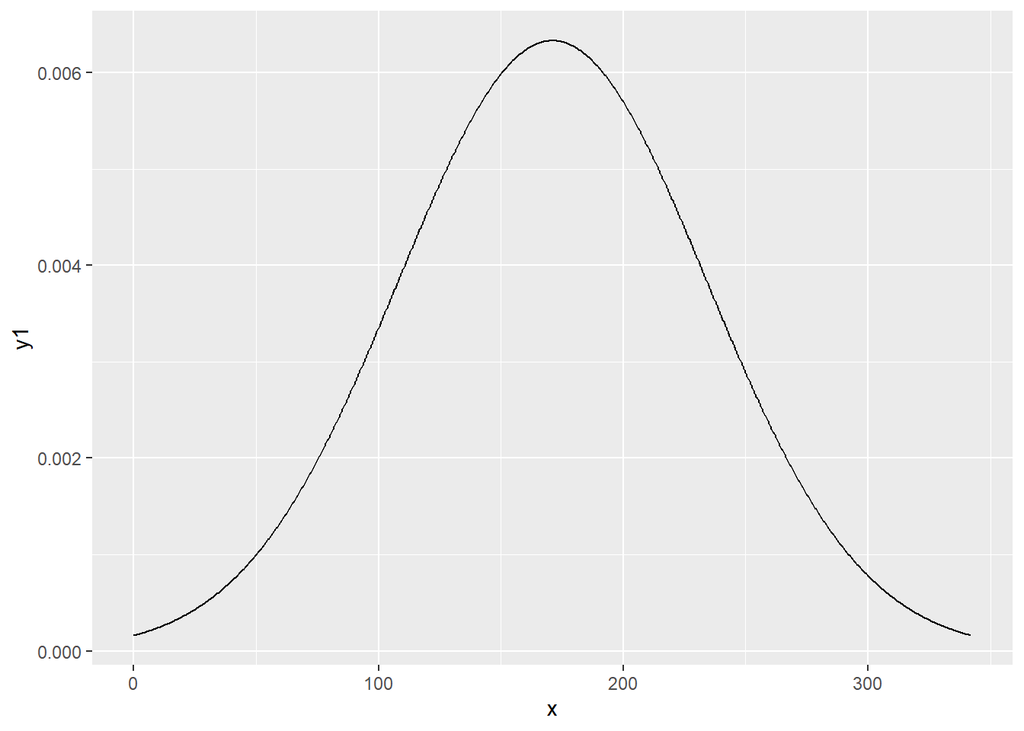

```r
x=seq(0,171*2,length.out = 1000)
y1=dnorm(x,mean = 171,sd = 63)
library(ggplot2)
qplot(x,y1,geom = 'line')
```

- You might think that is more than weakly informative! But remember, we are only making inference on the mean here, not the full sample. The sample mean is not likely to be above 250 or below 100, even if individuals may be that high or low. But perhaps you still think this prior is too strongly informative! In that case, we can manually set the prior ourselves to something less informative by passing in prior arguments.
- Perhaps you think we should allow a wider range of potential sample means - in that casem we could increase the standard deviation:

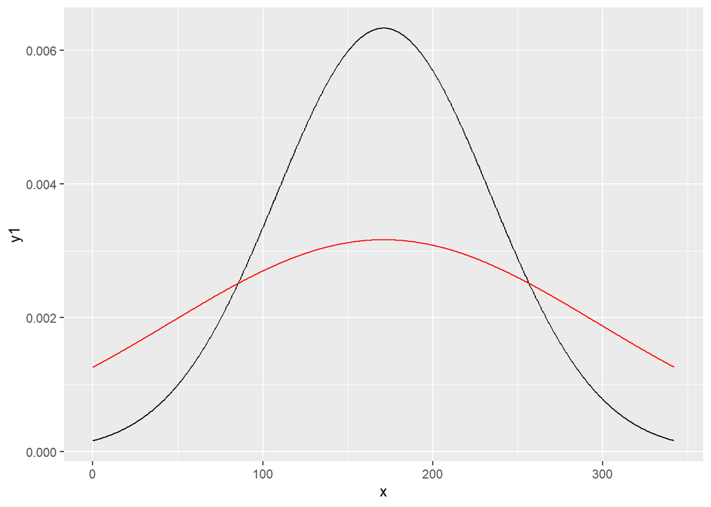

```r
x=seq(0,171*2,length.out = 1000)
y2=dnorm(x,mean = 171,sd = 63*2)
library(ggplot2)
qplot(x,y1,geom = 'line') +
  geom_line(color='red',aes(y=y2))
```

- Notice the prior is now more ‘flat’, indicating a prior belief that a wider range of sample means is possible.

- In the Bayesian framework, we combine these priors with the observed data, then get a posterior distribution.
- If we wanted to set the priors in the model call manually to that distribution , we could do this:

```r
# update the model
fit2 <- stan_glm(weights~1,
                 data=df1,
                 prior_intercept = normal(location = 171, # this is the sample mean
                                          scale = 5, # this will be interpreted as 5*SD since autoscale =T
                                          autoscale = T),
                 prior_aux = exponential(rate = 1,
                                         autoscale = T))
# Compare the models
coef(fit1)
```

```
## (Intercept)
##    170.5637
```

```r
coef(fit2)
```

```
## (Intercept)
##    171.1205
```

```r
# check the priors
prior_summary(fit2)
```

```
## Priors for model 'fit2'
## ------
## Intercept (after predictors centered)
##   Specified prior:
##     ~ normal(location = 171, scale = 5)
##   Adjusted prior:
##     ~ normal(location = 171, scale = 127)
##
## Auxiliary (sigma)
##   Specified prior:
##     ~ exponential(rate = 1)
##   Adjusted prior:
##     ~ exponential(rate = 0.039)
## ------
## See help('prior_summary.stanreg') for more details
```

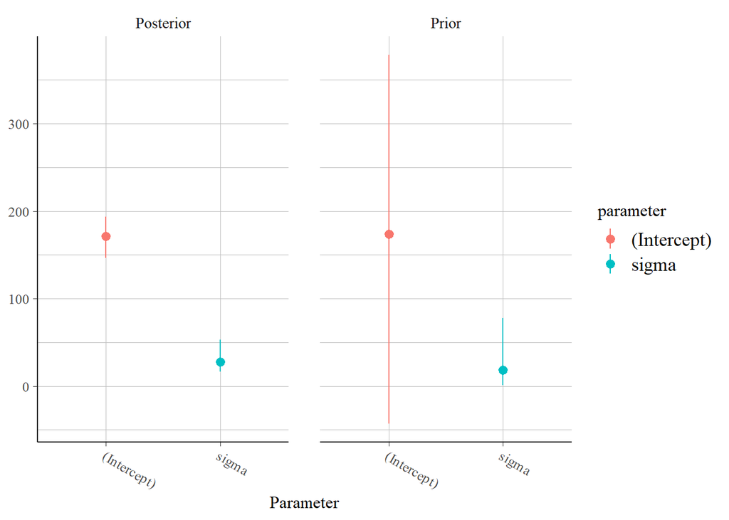

```r
posterior_vs_prior(fit2)
```

# Understanding the posterior output

- OK - so now we understand the prior’s going into the model. There is one prior distribution assigned for each model parameter, and then the output of the model (the posterior) includes the posterior distribution for each parameter. This posterior distribution summarizes the uncertainty in the parameters we are estimating.
- Let’s look back at the summary and focus on the estimates table:

```r
## Examine the second model output
summary(fit2)
```

```
##
## Model Info:
##  function:     stan_glm
##  family:       gaussian [identity]
##  formula:      weights ~ 1
##  algorithm:    sampling
##  sample:       4000 (posterior sample size)
##  priors:       see help('prior_summary')
##  observations: 5
##  predictors:   1
##
## Estimates:
##               mean   sd    10%   50%   90%
## (Intercept) 170.9   14.6 153.9 171.1 188.0
## sigma        30.1   11.8  18.5  27.5  45.0
##
## Fit Diagnostics:
##            mean   sd    10%   50%   90%
## mean_PPD 171.0   21.0 147.1 170.9 195.6
##
## The mean_ppd is the sample average posterior predictive distribution of the outcome variable (for details see help('summary.stanreg')).
##
## MCMC diagnostics
##               mcse Rhat n_eff
## (Intercept)   0.4  1.0  1393
## sigma         0.3  1.0  1330
## mean_PPD      0.5  1.0  2112
## log-posterior 0.0  1.0  1034
##
## For each parameter, mcse is Monte Carlo standard error, n_eff is a crude measure of effective sample size, and Rhat is the potential scale reduction factor on split chains (at convergence Rhat=1).
```

```r
## look at the estimates (coefficients)
coef(fit2)
```

```
## (Intercept)
##    171.1205
```

```r
# Extract the posterior sample and put in dataframe
fit2_posterior <-
  as.data.frame(fit2)
head(fit2_posterior)
```

```
##   (Intercept)    sigma
## 1    183.8757 20.51181
## 2    179.2112 21.02876
## 3    174.9040 17.57459
## 4    160.5086 21.91707
## 5    169.1350 24.44243
## 6    174.1333 19.56207
```

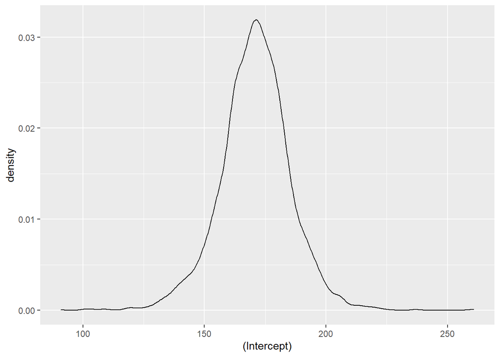

```r
# visualize the posterior (intercept)
ggplot(fit2_posterior,aes(x=`(Intercept)`)) + geom_density()
```

- We can now summarize this distribution to make inference on how likely any given value is. The most likely value may be the mean or the median -

```r
# Posterior mean
mean(fit2_posterior$`(Intercept)`)
```

```
## [1] 170.8541
```

```r
# Posterior median
median(fit2_posterior$`(Intercept)`)
```

```
## [1] 171.1205
```

- We are 90 percent confident the intercept is between these two numbers:

```r
# Quantiles for posterior
quantile(fit2_posterior$`(Intercept)`,
         probs = c(0.05,0.95))
```

```
##       5%      95%
## 146.7655 193.7521
```

- The summary table chooses a few summaries by default - but you can access the posterior and make your own summaries.

```r
# What is the probability that the intercept is greater than 100?
sum(fit2_posterior$`(Intercept)`>100)/length(fit2_posterior$`(Intercept)`)
```

```
## [1] 0.99975
```

```r
# What is the probability that the intercept is greater than 200?
sum(fit2_posterior$`(Intercept)`>200)/length(fit2_posterior$`(Intercept)`)
```

```
## [1] 0.02225
```

- There are some automatic plotting functions for this as well:

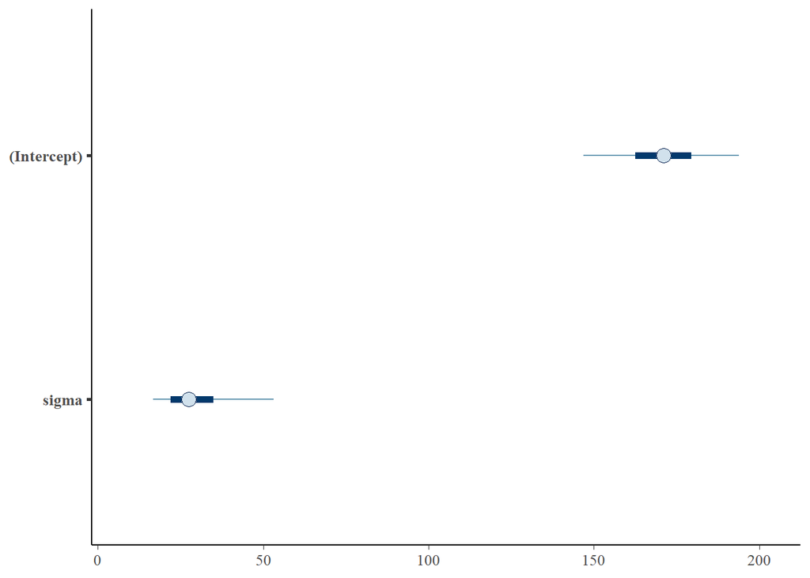

```r
# Plotting method from rstanarm
plot(fit2)
```

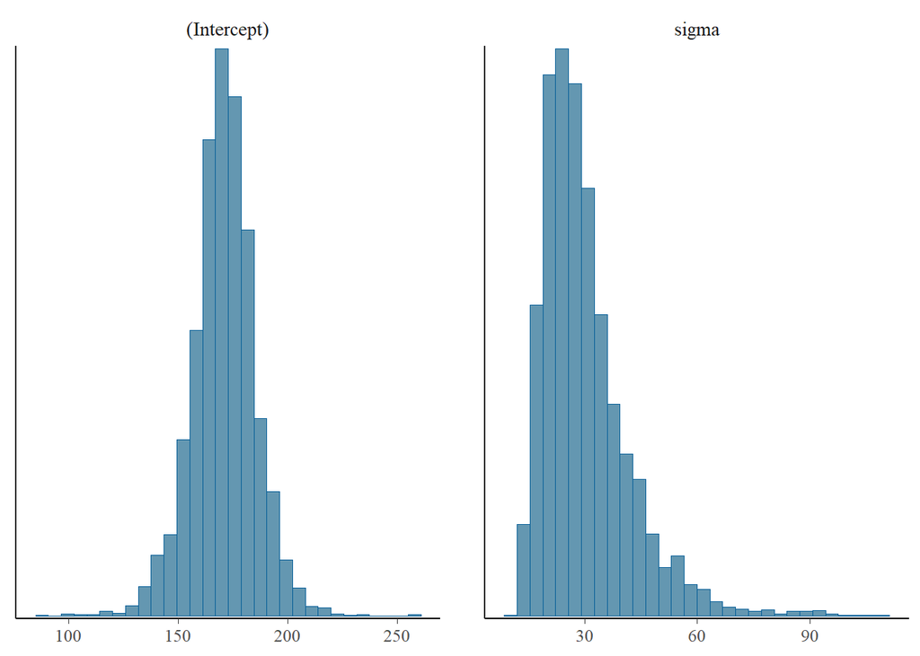

```r
# use the bayesplot package for more functionality
library(bayesplot)
mcmc_hist(fit2)
```

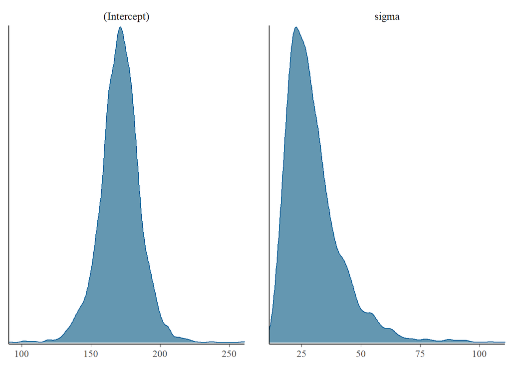

```r
mcmc_dens(fit2)
```

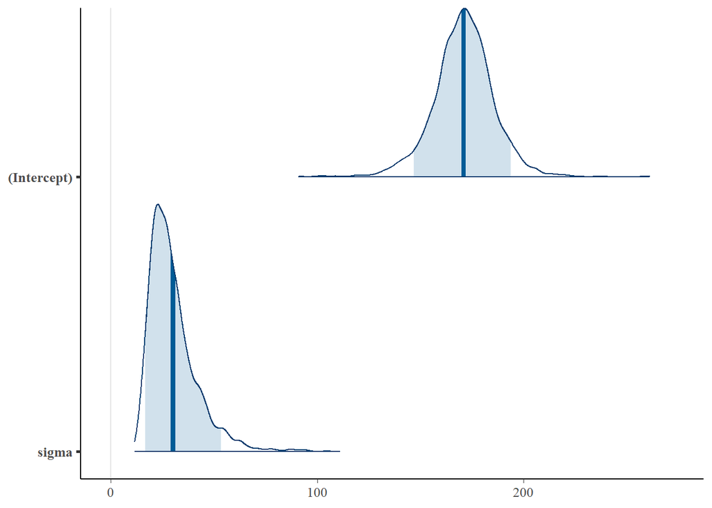

```r
mcmc_areas(fit2,
           prob=0.9, # 90 percent intervals
           point_est = 'mean' # middle is the mean
           )
```

- Since we have a posterior distribution, we have much more flexibility in summarizing and interpreting the models.

# Non-informative Priors

- You may have heard about non-informative priors. This is the idea that if we have no information about the expected result of the experiment, we can use a non-informative prior which will allow the result to be whatever the data says. This is also called a ‘flat’ prior. This can be accomplished by assigning the prior to NULL in the model call.
- However, this is not generally a good idea! This is because a ‘non-informative prior’ gives too much weight to highly improbable or even impossible values. Instead, we should use ‘weakly-informative’ priors, which are the default priors in each rstanarm model call.

```r
# Fit 'non-informative (flat) priors
fit3 <- stan_glm(weights~1,
                 data=df1,
                 prior_intercept = NULL,
                 prior_aux = NULL)
fit3
```

```
## stan_glm
##  family:       gaussian [identity]
##  formula:      weights ~ 1
##  observations: 5
##  predictors:   1
## ------
##             Median MAD_SD
## (Intercept) 170.9   15.6
##
## Auxiliary parameter(s):
##       Median MAD_SD
## sigma 34.0   15.2
##
## ------
## * For help interpreting the printed output see ?print.stanreg
## * For info on the priors used see ?prior_summary.stanreg
```

```r
prior_summary(fit3)
```

```
## Priors for model 'fit3'
## ------
## Intercept (after predictors centered)
##  ~ flat
##
## Auxiliary (sigma)
##  ~ flat
## ------
## See help('prior_summary.stanreg') for more details
```

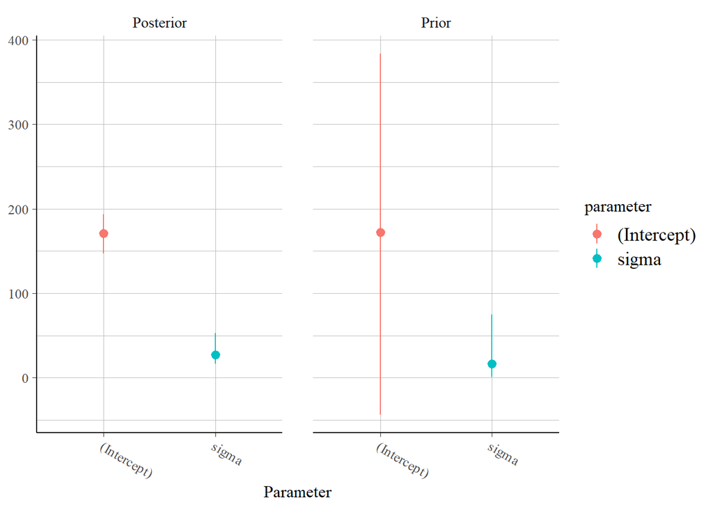

```r
# notice the big range in the 'flat' prior
posterior_vs_prior(fit2)
```

# Specifying an Informative Prior

- Perhaps we have some prior information about the distribution of human weights, and we wish to include it in the prior. We must express this belief in terms of a probability distribution. Let’s use the normal distribution for now, and see what the effect is on the results. I am going to implement different priors and we can see how it affects the end result.
- We think that the average human weight is most likely 150, and express our uncertainty with a SD of 30.

```r
# fit model with informative prior
fit4 <- stan_glm(weights~1,
                 data=df1,
                 prior_intercept = normal(150,30,autoscale = FALSE),
                 prior_aux = cauchy(location = 0, scale = 5))
```

- Now we summarize the model:

```r
# Summarize the model
summary(fit4)
```

```
##
## Model Info:
##  function:     stan_glm
##  family:       gaussian [identity]
##  formula:      weights ~ 1
##  algorithm:    sampling
##  sample:       4000 (posterior sample size)
##  priors:       see help('prior_summary')
##  observations: 5
##  predictors:   1
##
## Estimates:
##               mean   sd    10%   50%   90%
## (Intercept) 168.1   11.4 153.8 168.7 181.3
## sigma        26.8   10.6  17.0  24.2  39.8
##
## Fit Diagnostics:
##            mean   sd    10%   50%   90%
## mean_PPD 168.1   17.1 147.4 168.4 187.7
##
## The mean_ppd is the sample average posterior predictive distribution of the outcome variable (for details see help('summary.stanreg')).
##
## MCMC diagnostics
##               mcse Rhat n_eff
## (Intercept)   0.3  1.0  1784
## sigma         0.3  1.0  1224
## mean_PPD      0.3  1.0  2562
## log-posterior 0.0  1.0  1060
##
## For each parameter, mcse is Monte Carlo standard error, n_eff is a crude measure of effective sample size, and Rhat is the potential scale reduction factor on split chains (at convergence Rhat=1).
```

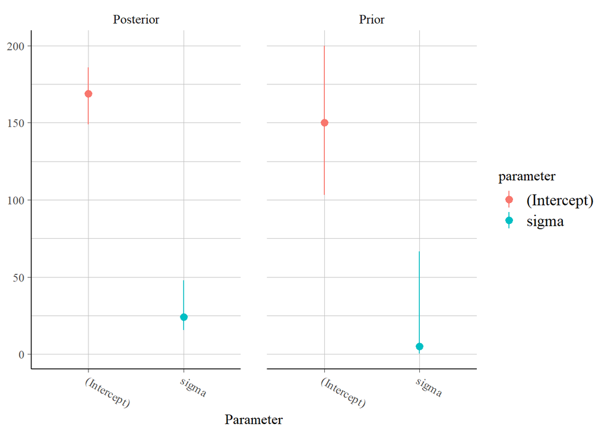

```r
# Generate automatic plot to compare
posterior_vs_prior(fit4)
```

- How did this effect our parameter estimates? Let’s compare our result to the ‘weakly informative’ model we fit above.

```r
# informative model estimate
coef(fit4)
```

```
## (Intercept)
##    168.7458
```

```r
# weakly informative model estiamte
coef(fit2)
```

```
## (Intercept)
##    171.1205
```

- Notice the estimated mean is lower here. It is now a balance between the informative prior (mean weight is 150) and the actual data (mean weight is 171). The balance between the data and prior is based on the SD of the prior!. Let’s change that and see what happens.

```r
# fit model with informative prior
fit5 <- stan_glm(weights~1,
                 data=df1,
                 prior_intercept = normal(150,
                                          5, # strong prior here!
                                          autoscale = FALSE),
                 prior_aux = cauchy(location = 0, scale = 5))
# really strong prior
coef(fit5)
```

```
## (Intercept)
##    153.2171
```

```r
# informative model estimate (moderate prior)
coef(fit4)
```

```
## (Intercept)
##    168.7458
```

```r
# weakly informative model estimate
coef(fit2)
```

```
## (Intercept)
##    171.1205
```

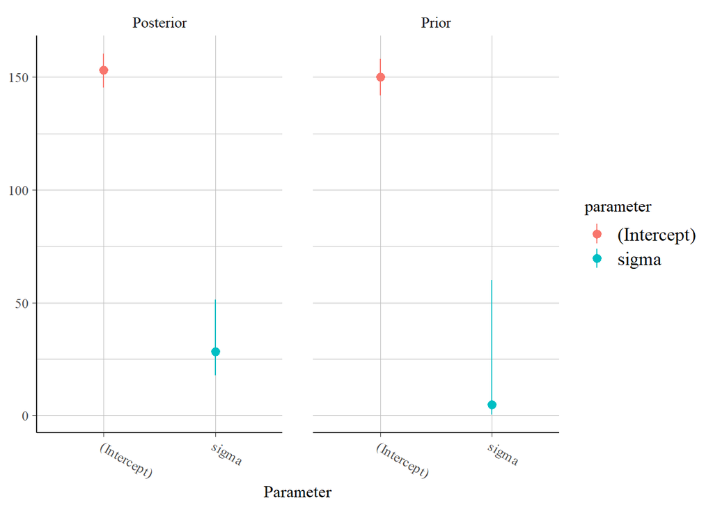

```r
# Generate automatic plot to compare
posterior_vs_prior(fit5)
```

- Do you see how this works functionaly? We must be careful about expressing strong priors. If we do, our results will essentially be the prior with the data having little effect on the posterior.

# Exploring the Posterior

- There are a number of tools to explore the posterior distribution from an MCMC model like the one fit with rstanarm. Recall, the actual ‘output’ of the model is a distribution of values for each parameter in the model, in this case just $\mu$ and $\sigma$

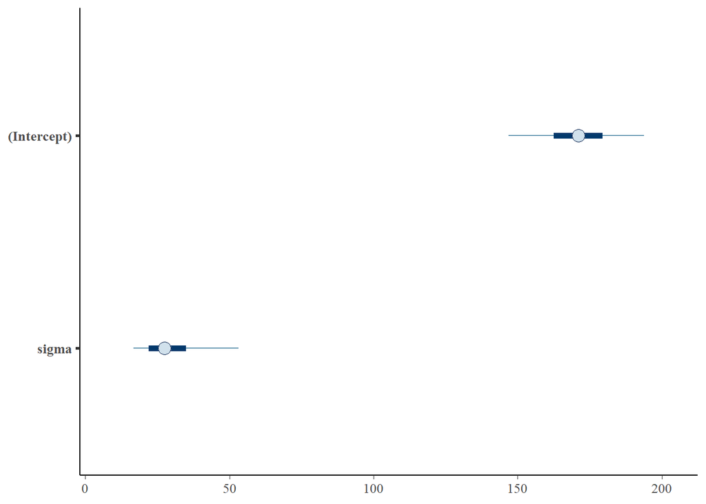

```r
# Plot the distribution of the parameters
plot(fit2)
```

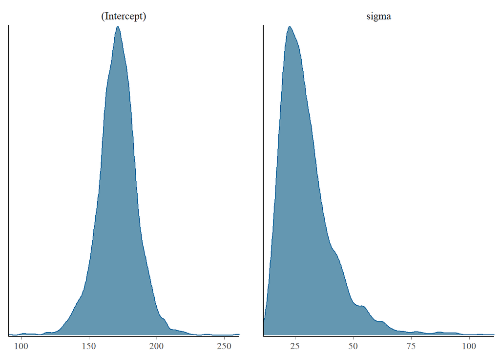

```r
# plot the density
plot(fit2, plotfun = "mcmc_dens")
```

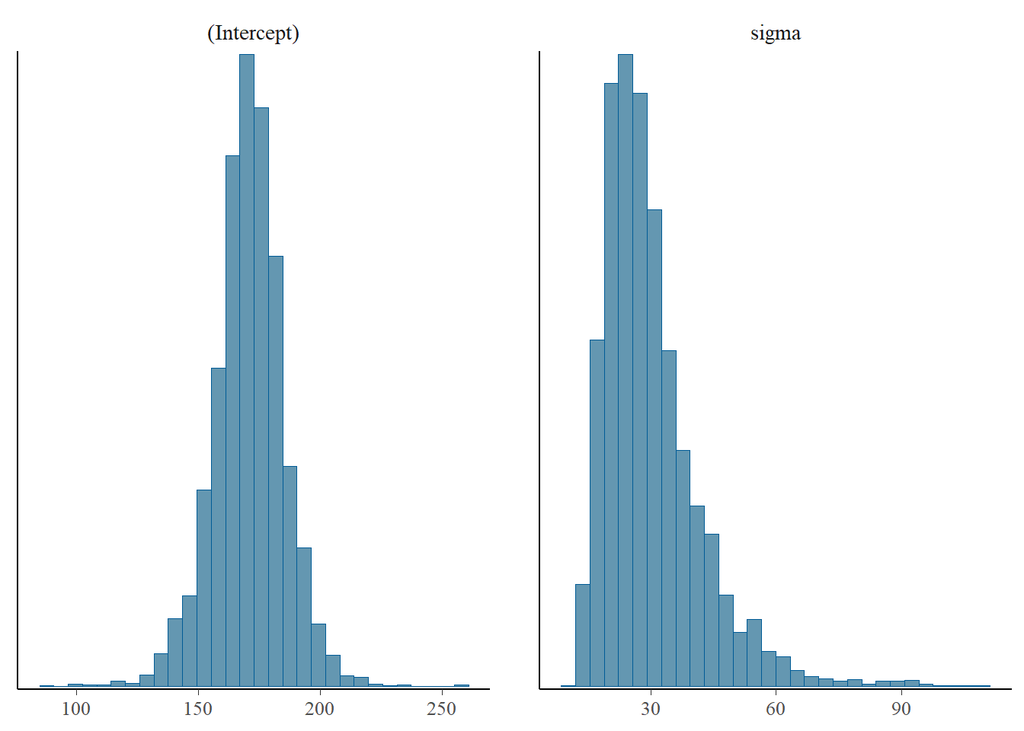

```r
# plot histograms
plot(fit2, plotfun = "mcmc_hist")
```

- We can also look at the distribution of the outcome of the model (make predictions based on the model) using the `posterior_predict()` function. In the case of our simple model, we have estimated a single mean, so it doesn’t matter what value of weight we put in. We will revisit this in the context of building more complex models later. This function will make random draws from the posterior distribution for someone with the covariates of interest. In this model, we have no covariates - (intercept only model). So we can pass in a simple dataframe with just an intercept value of 1.

```r
# make predictions for this new person (draws from the posterior)
posterior_result1 <-
  posterior_predict(fit2,
                    newdata = data.frame(weight=1))
head(posterior_result1) # matrix with one column
```

```
##             1
## [1,] 178.2894
## [2,] 134.2116
## [3,] 198.7627
## [4,] 166.4126
## [5,] 184.9384
## [6,] 168.1295
```

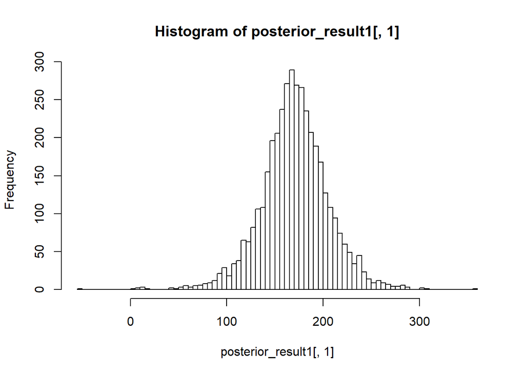

```r
# visualize these predictions
hist(posterior_result1[,1],
     breaks = 100)
```

- Wait a minute - I thought earlier we said there was a very low chance of the mean weight (the intercept) being above 200?

```r
# Probability of sample mean being above 200
sum(as.data.frame(fit2)$`(Intercept)` > 200)/length(as.data.frame(fit2)$`(Intercept)`)
```

```
## [1] 0.02225
```

```r
# how many of these values are above 200?
sum(posterior_result1[,1]>200)/length(posterior_result1[,1])
```

```
## [1] 0.1715
```

# Conclusion

In the lecture we gave an overview/introduction to the Bayesian approach to making inference. We started with the notion of Bayes theorum, then related it to making inference using priors and data to estimate posterior distributions of parameters.

- We will often see a similar result in a Bayesian model compared to a similar frequentist model if we are studying the middle of the distribution (means), and we use weakly informative parameters.
- However, the Bayesian approach gives us more flexability by providing a full posterior distribution.
- The downside is the computational time required to fit the model (the MCMC process), and the added complexity of specifying priors for the models.
- We will explore Bayesian regression modeling approaches in details in the subsequent lectures.